# Ribosome profiling analysis

Author: Joyce Hsiao

Last updated: 2015-08-19 01:50:01

view source

```r
library(Biobase)

## Set working directories
dir <- "../"
figdir <- file.path(dir,"figures")
rdadir <- file.path(dir,"rdas")
datadir <- file.path(dir, "data")

## Use broman package for colors
require(broman)
crayon <- brocolors("crayons")

## Load customized packages
require(devtools)
require(Humanzee)

## Load eSet of Ribosome profiling data only
load(file=file.path(rdadir,"eSetRiboProfile.rda"))
```

# Overview

> Ribosome profiling data of `10050` genes were included in the comparative anaysis of gene-level ribosome protected fragment counts. These genes met the filtering criteria of 1) being quantified with sufficient number of samples in the comparative analysis of human versus chimp or human versus rhesus, and 2) being quantified in at least 3 samples among each species (> 0 count). The data set before filtering contain `28644` genes.

> Comparative analysis of ribosome protected fragment coverage was performed on 1) RPKM values after standardizing with respect to GM19238, followed by qunantile normalization; and, 2) RPKM values before standardizing with respect ot GM19238, followed by quantile normalization. In the data with raw RPKM values, the sample GM19238 was removed from the analysis for a fair comparison of results between analyses based on standardized RPKM values and unstandardized RPKM values.

```r
# Make expression data set from read count table
source(file.path(codedir,"makeExpressionSet_ribo.r"))
riboCountFiles <- list.files(file.path(dir,"data/ribo"),
                             pattern="*_081514.table",full.name=TRUE)
makeSet <- makeExpressionSet_ribo(riboCountFiles)
eSet.ribo <- makeSet$eSet

# Remove reference cell line from the expression set
eSet.ribo.none <- eSet.ribo[,eSet.ribo$celline!="H19238"]

# Filtering: include only genes quantified in 3 or more samples
# in all three species
species <- unique(eSet.ribo.none$species)
ii.species <- lapply(1:length(species),function(j) {
      temp.mat <- exprs(eSet.ribo.none)[,eSet.ribo.none$species==species[j]]>0
      rowSums(temp.mat) > 2
})
names(ii.species) <- species
ii.species <- data.frame(do.call(cbind,ii.species))
ii.filt <- ii.species$human*ii.species$chimp*ii.species$rhesus==1
eSet.ribo.none.f <- eSet.ribo.none[ii.filt,]

# Compute RPKM values
ribo.rpkm <- 100*( t(t(exprs(eSet.ribo.none.f) )/
                colSums(exprs(eSet.ribo.none.f)))*(10^6))/
                fData(eSet.ribo.none.f)$len

# Replace the zero RPKM with NA's
ii.zero <- which(ribo.rpkm == 0,arr.ind=TRUE)
for (i in 1:dim(ii.zero)[1]) {
  ribo.rpkm[ii.zero[i,1], ii.zero[i,2]] = NA
}

# Qunatile normalize the RPKM values
source(file.path(codedir,"normalizationMethods.r"))
ribo.rpkm.nos.q <- normalize(ribo.rpkm,method="quantile",log=FALSE)

# Make an expression set of ribosome profiling RPKM values
# quantie-normalized across species
# Exclude the standard cell line
eSet.ribo.rpkm.nos.q <-
  ExpressionSet(assayData = as.matrix(log2(ribo.rpkm.nos.q)),
                phenoData = new("AnnotatedDataFrame",
                        data = pData(eSet.ribo.none.f)),
                experimentData <- experimentData(eSet.ribo.none.f))
featureData(eSet.ribo.rpkm.nos.q) <- featureData(eSet.ribo.none.f)


# Compute relative RPKM
# Only keep genes quantified with more than 1 read in the
# internal standard cell line
idx.gene.filt <- fData(eSet.ribo.none.f)$ENSGID
idx.gene.ref <- which(fData(eSet.ribo)$ENSGID %in% idx.gene.filt)
gene.ref <- exprs(eSet.ribo[idx.gene.ref,eSet.ribo$celline=="H19238"])
gene.ref <- gene.ref[gene.ref!=0, ]

eSet.ribo.none.f <- eSet.ribo.none.f[ which(fData(eSet.ribo.none.f)$ENSGID %in% names(gene.ref)),]

ribo.rpkm <- 100*(t(t(exprs(eSet.ribo.none.f))/
                 colSums(exprs(eSet.ribo.none.f)))*(10^6) )/
                 fData(eSet.ribo.none.f)$len

ribo.rpkm.std <- 100*(gene.ref/sum(gene.ref))*(10^6)/fData(eSet.ribo.none.f)$len
ribo.rpkm.s <- ribo.rpkm/ribo.rpkm.std

# Replace the zero standardized RPKM with NA's
ii.zero <- which(ribo.rpkm.s==0,arr.ind=TRUE)
for (i in 1:dim(ii.zero)[1]) {
  ribo.rpkm.s[ii.zero[i,1],ii.zero[i,2]] = NA
}

# Qunatile normalize the standarized RPKM values
source(file.path(codedir,"normalizationMethods.r"))
ribo.rpkm.q <- normalize(ribo.rpkm.s,method="quantile",log=FALSE)

eSet.ribo.rpkmq <- ExpressionSet(assayData=as.matrix(log2(ribo.rpkm.q)),
                phenoData=new("AnnotatedDataFrame",
                        data=pData(eSet.ribo.none.f)),
                experimentData=experimentData(eSet.ribo.none.f))
featureData(eSet.ribo.rpkmq)<-featureData(eSet.ribo.none.f)


# Differential expression anaysis
# on the relative RPKM values
source(file.path(codedir,"DEtesting.r"))
ribo.Res.hc <- testDE(eSet.ribo.rpkmq,seqData="ribo",
                      species=c("human","chimp"))$res
ribo.Res.hr <- testDE(eSet.ribo.rpkmq,seqData="ribo",
                      species=c("human","rhesus"))$res
ribo.Res.rc <- testDE(eSet.ribo.rpkmq,seqData="ribo",
                      species=c("chimp","rhesus"))$res

# Differential expression testing on
# the RPKM values
source(file.path(codedir,"DEtesting.r"))
ribo.Res.hc.nos <- testDE(eSet.ribo.rpkm.nos.q,seqData="ribo",
                          species=c("human","chimp"))$res
ribo.Res.hr.nos = testDE(eSet.ribo.rpkm.nos.q,seqData="ribo",
                         species=c("human","rhesus"))$res
ribo.Res.rc.nos = testDE(eSet.ribo.rpkm.nos.q,seqData="ribo",
                         species=c("chimp","rhesus"))$res

save(eSet.ribo.none,eSet.ribo.none.f,
     ribo.rpkm.s,ribo.rpkm.q,ribo.rpkm,
     eSet.ribo.rpkmq,ribo.Res.hc,ribo.Res.hr,ribo.Res.rc,
     eSet.ribo.rpkm.nos.q,ribo.Res.hc.nos,ribo.Res.hr.nos,ribo.Res.rc.nos,
     file=file.path(rdadir,"eSetRiboProfile.rda"))
```

# Sequencing depth and gene count distributions

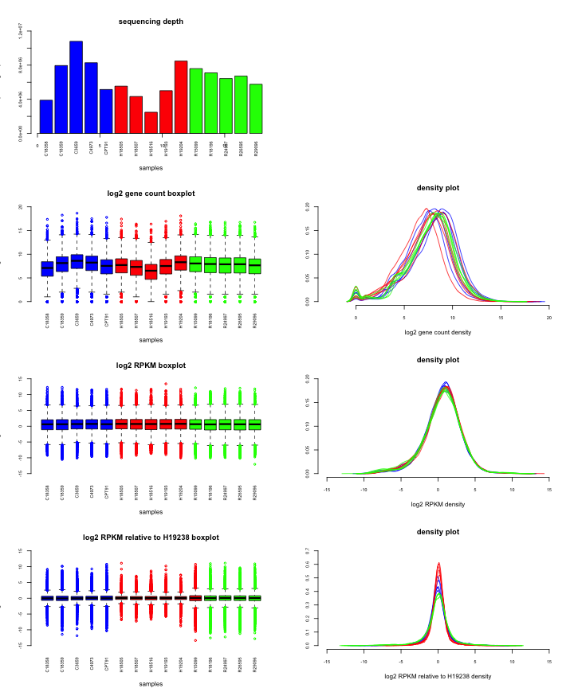

```r
par(mfrow=c(4,2),cex.axis=.7,cex.main=1.2)

# sequencing depth
barplot(colSums(exprs(eSet.ribo.none.f),na.rm=T),
        col=c(rep("blue",5),rep("red",5),rep("green",5)) ,axes=F,ylim=c(0,12e+06),las=2)
axis(1);axis(2)
title(xlab="samples",ylab="sequencing depth",line=4)
title(main="sequencing depth",line=1)

plot(0,pch="",axes=F,xlab="",ylab="",main="")

# gene count boxplots
boxplot(log2(exprs(eSet.ribo.none.f)),
        col=c(rep("blue",5),rep("red",5),rep("green",5)),ylim=c(0,20),
        outcol=c(rep("blue",5),rep("red",5),rep("green",5)),axes=F,main="",xlab="",ylab="")
axis(1,at=seq(1,15,1),labels=c(eSet.ribo.none.f$celline),las=2,tick=F)
axis(2)
title(xlab="samples",ylab="log2-count",line=4)
title(main="log2 gene count boxplot",line=1)

plot(0,pch="",xlim=c(-3,20),ylim=c(0,.2),xlab="",ylab="",axes=F)
axis(1);axis(2)
for (ss in seq_along(c("chimp","human","rhesus"))) {
  ii = eSet.ribo.none.f$species==c("chimp","human","rhesus")[ss]
  mat = log2(exprs(eSet.ribo.none.f)[ii,])
  for (i in 1:sum(ii)) {
    lines(density(log2(exprs(eSet.ribo.none.f))[,ii][,i],na.rm=T),
          col=c("blue","red","green")[ss])
    }
  }
title(xlab="log2 gene count density",main="density plot")

# log2 RPKM plots (unstandardized)
boxplot(log2(ribo.rpkm),
        col=c(rep("blue",5),rep("red",5),rep("green",5)), ylim=c(-15,15),
        outcol=c(rep("blue",5),rep("red",5),rep("green",5)),
        axes=F,main="",xlab="",ylab="")
axis(1,at=seq(1,15,1),labels=c(eSet.ribo.none.f$celline),las=2,tick=F)
axis(2)
title(xlab="samples",ylab="log2-RPKM",line=4)
title(main="log2 RPKM boxplot",line=1)

plot(0,pch="",xlim=c(-15,15),ylim=c(0,.2),xlab="",ylab="",axes=F)
axis(1);axis(2)
for (ss in seq_along(c("chimp","human","rhesus"))) {
  ii = eSet.ribo.none.f$species==c("chimp","human","rhesus")[ss]
  for (i in 1:sum(ii)) {
    lines(density(log2(ribo.rpkm)[,ii][,i],na.rm=T),
          col=c("blue","red","green")[ss])
    }
  }
title(xlab="log2 RPKM density",main="density plot")

# log2 RPKM plots (standardized)
boxplot(log2(ribo.rpkm.s),
        col=c(rep("blue",5),rep("red",6),rep("green",5)),ylim=c(-15,15),
        outcol=c(rep("blue",5),rep("red",6),rep("green",5)),
        axes=F,main="",xlab="",ylab="")
axis(1,at=seq(1,15,1),labels=c(eSet.ribo.none.f$celline),tick=F,las=2)
axis(2)
title(xlab="samples",ylab="log2-count",line=4)
title(main="log2 RPKM relative to H19238 boxplot",line=1)

ribo.rpkm.s.foo <- ribo.rpkm.s[,-11]
species = eSet.ribo.none.f$species[-11]
plot(0,pch="",xlim=c(-15,15),ylim=c(0,.7),xlab="",ylab=""
     ,axes=F)
axis(1);axis(2)
for (ss in seq_along(c("chimp","human","rhesus"))) {
  ii = species==c("chimp","human","rhesus")[ss]
  for (i in 1:sum(ii)) {
    lines(density(log2(ribo.rpkm.s.foo)[,ii][,i],na.rm=T),
          col=c("blue","red","green")[ss])
    }
  }
title(xlab="log2 RPKM relative to H19238 density",main="density plot")
```

# DE testing results (relative RPKM)

## MA plots and volcano plots

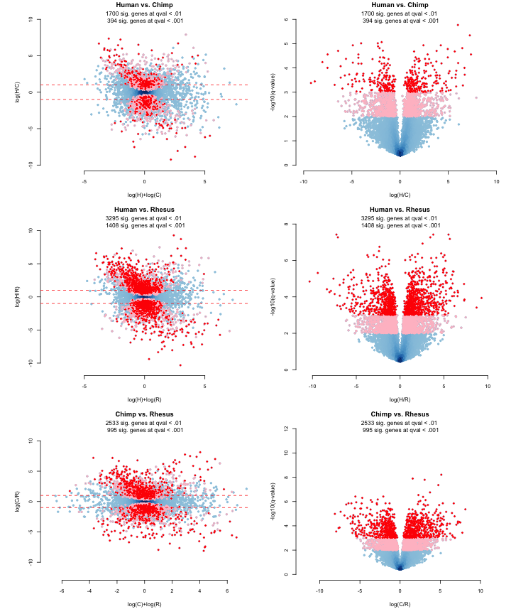

### Check outlier genes in the human-versus-chimp comparison

> The outlier genes in the analysis based on standardized RPKM values also have a significant, but smaller fold change (q-value < .01) in analysis based on unstandardized RPKM values. Looking closer at the expression levels based on each data transformation, the expression levels based on standardized RPKM values have a bigger fold change between human and chimp.

## Distribution of fold change of between-species comparisons

### Significant genes versus non-significant genes

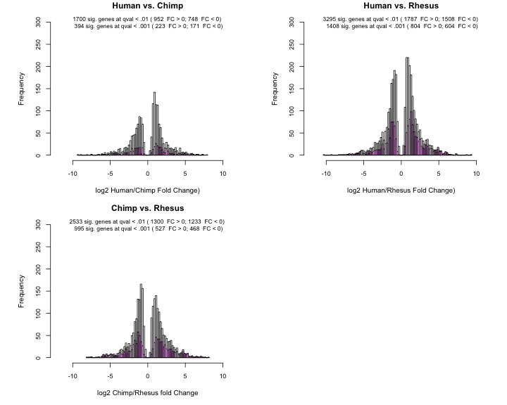

### Distribution of fold change of significant genes in human-versus-chimp comparsion versus human-versus-rhesus comparison

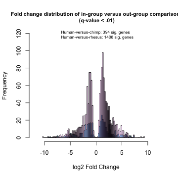

## p-value distribution

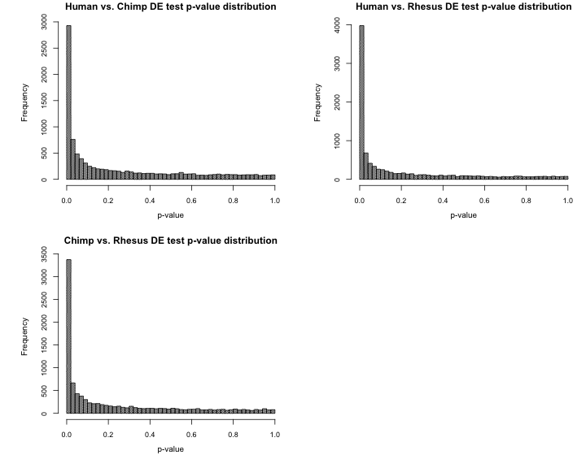

## Overlap of significant genes at q-value < .01

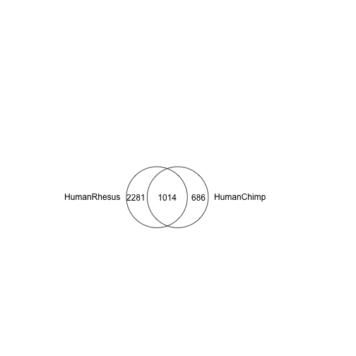

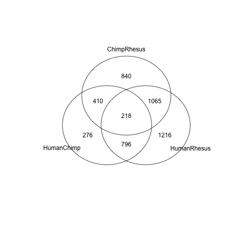

## Overlap of significant genes at q-value < .001

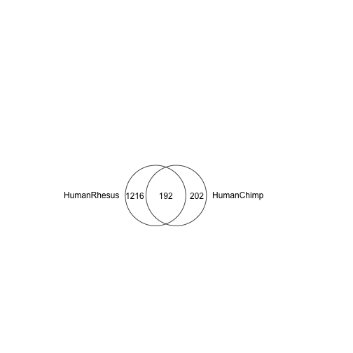

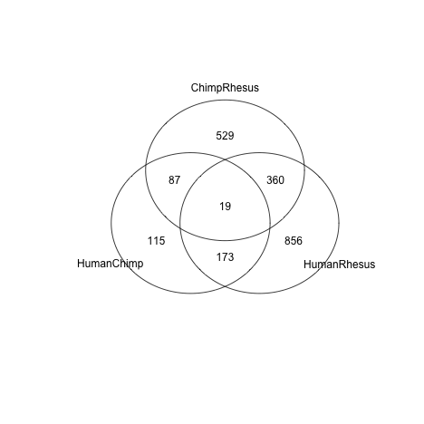

## Comparative analysis of fold change (q-value < .001)

### Human versus Chimp and Rhesus

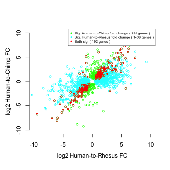

# DE testing results using the unstandardized RPKM values

## MA plots and volcano plots

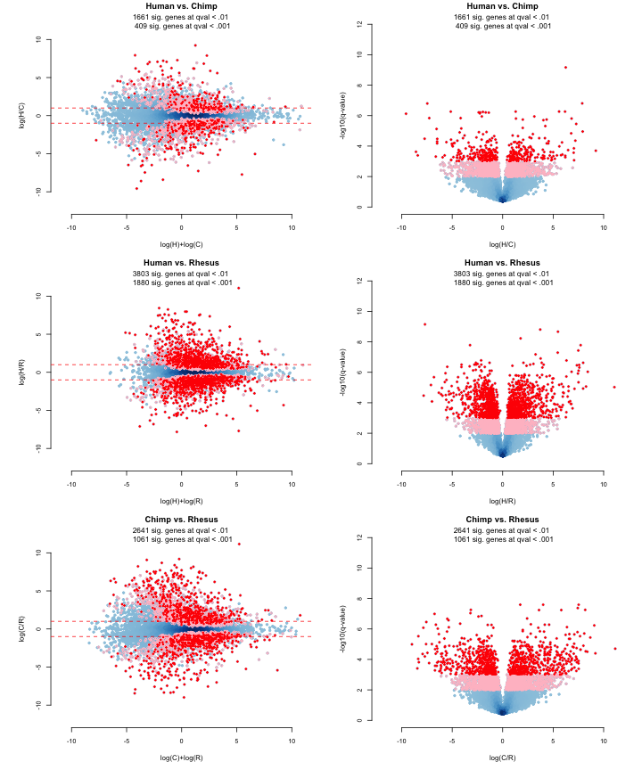

## Fold-change distribution of significant genes

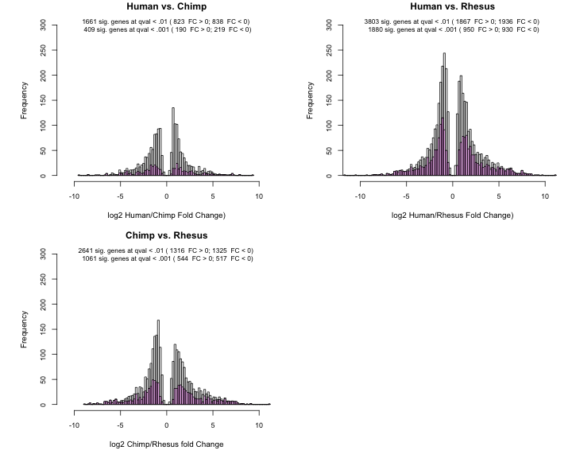

## p-value distribution

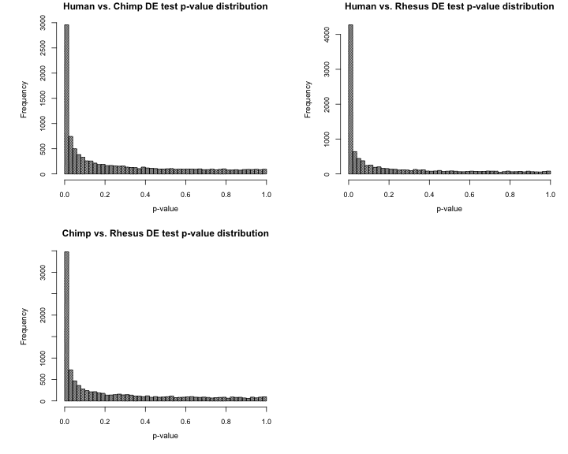

## Overlap of significant genes at q-value < .01

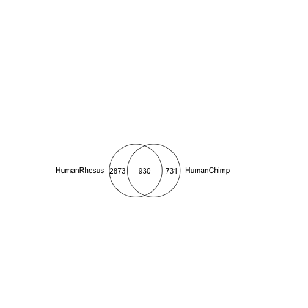

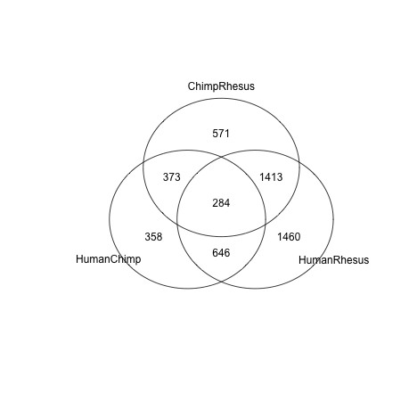

## Overlap of significant genes at q-value < .001

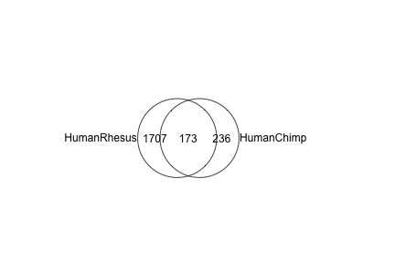

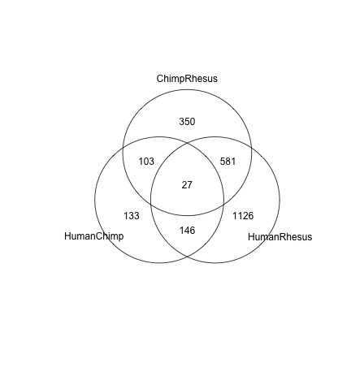

## Comparative analysis of fold change (q-value < .001)

### Human versus Chimp and Rhesus

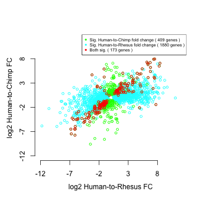

# Compare DE results of standardized RPKM values and unstandardized RPKM values

## Human versus Chimp: Overlap of significant genes at q-value < .001

### All signficant genes

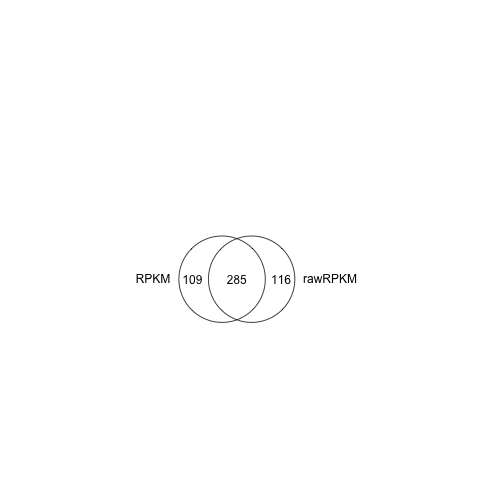

### Signficant Human > Chimp

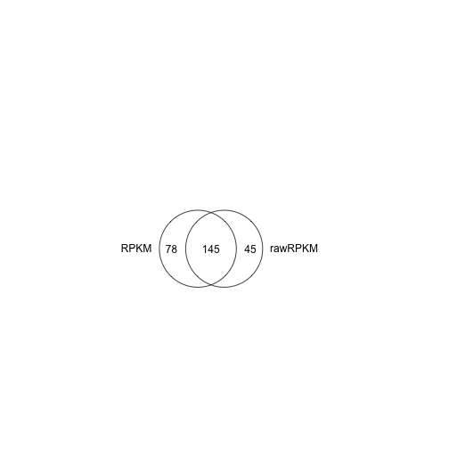

### Signficant Human < Chimp

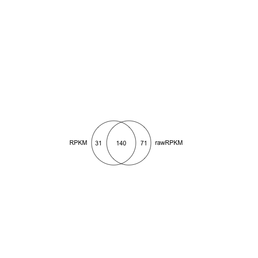

## Human versus Rhesus: Overlap of significant genes at q-value < .001

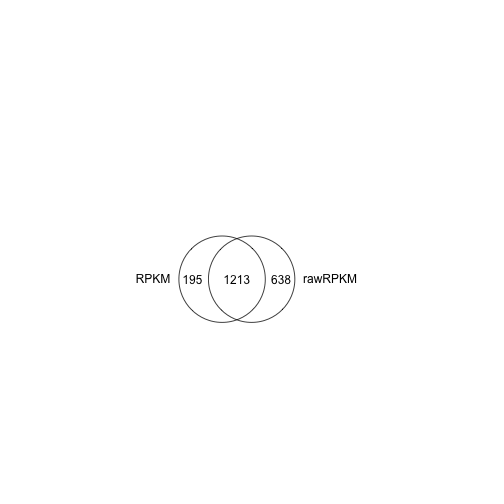

### Signficant Genes with Human > Rhesus

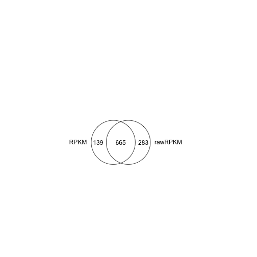

### Signficant Genes with Human < Rhesus

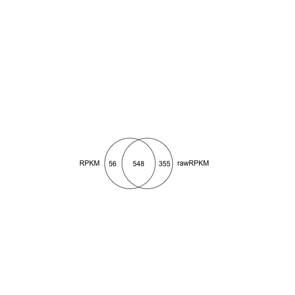

## Chimp versus Rhesus: Overlap of significant genes at q-value < .001

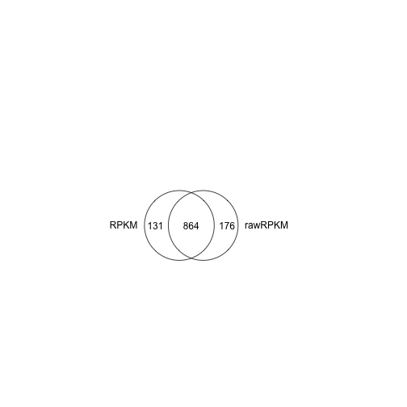

### Signficant Genes with Chimp > Rhesus

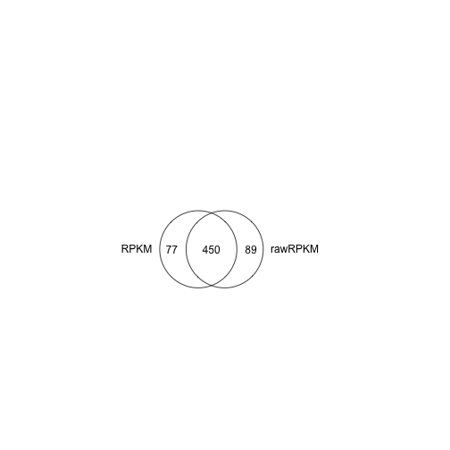

### Signficant Genes with Chimp < Rhesus

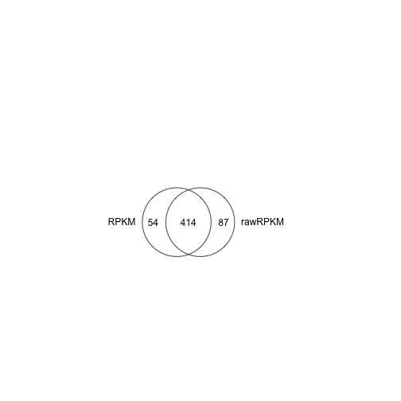

Styled with knitrBootstrap